# Part I - Prosper Loan Data Exploration

## Developed by Monica Iddah

## Introduction

Prosper Loan is a loan services system that renders loan to people from all round the united states.

The loan application system contains 113,937 applications with 81 different types of information or variables. The variables in the dataset include but not limited to:(ListingCreationDate, ListingNumber, ListingKey, EmploymentStatus, EmploymentStatusDuration, Occupation, IncomeRange, StatedMonthlyIncome, IncomeVerifiable, LoanOriginalAmount, LoanOriginationDate, MonthlyLoanPayment, DateCreditPulled, Recommendations, LoanStatus, Term, PercentFunded, ClosedDate, IsBorrowerHomeowner, InvestmentFromFriendsCount, InvestmentFromFriendsAmount, Investors)

The dataset would be explored upon the listed variables in the following three dimensions (Univariate, Bivariate and Multivariate exploration) inorder to achieve the correlation and relationship there exist amongst the dataset.

## Preliminary Wrangling

The libraries neccessary for the analysis would be imported and the dataset would be read in .csv file format

```python
# import all packages and set plots to be embedded inline
import numpy as np
import pandas as pd
import matplotlib.pyplot as plt
import seaborn as sb
import plotly.graph_objects as go
from plotly.subplots import make_subplots
%matplotlib inline

df = pd.read_csv('ProsperLoanData.csv')
df.head(5)
```

|  | ListingKey | ListingNumber | ListingCreationDate | CreditGrade | Term | LoanStatus | ClosedDate | BorrowerAPR | BorrowerRate | LenderYield | ... | LP_ServiceFees | LP_CollectionFees | LP_GrossPrincipalLoss | LP_NetPrincipalLoss | LP_NonPrincipalRecoverypayments | PercentFunded | Recommendations | InvestmentFromFriendsCount | InvestmentFromFriendsAmount | Investors |
| --- | --- | --- | --- | --- | --- | --- | --- | --- | --- | --- | --- | --- | --- | --- | --- | --- | --- | --- | --- | --- | --- |
| 0 | 1021339766868145413AB3B | 193129 | 2007-08-26 19:09:29.263000000 | C | 36 | Completed | 2009-08-14 00:00:00 | 0.16516 | 0.1580 | 0.1380 | ... | -133.18 | 0.0 | 0.0 | 0.0 | 0.0 | 1.0 | 0 | 0 | 0.0 | 258 |
| 1 | 10273602499503308B223C1 | 1209647 | 2014-02-27 08:28:07.900000000 | NaN | 36 | Current | NaN | 0.12016 | 0.0920 | 0.0820 | ... | 0.00 | 0.0 | 0.0 | 0.0 | 0.0 | 1.0 | 0 | 0 | 0.0 | 1 |
| 2 | 0EE9337825851032864889A | 81716 | 2007-01-05 15:00:47.090000000 | HR | 36 | Completed | 2009-12-17 00:00:00 | 0.28269 | 0.2750 | 0.2400 | ... | -24.20 | 0.0 | 0.0 | 0.0 | 0.0 | 1.0 | 0 | 0 | 0.0 | 41 |
| 3 | 0EF5356002482715299901A | 658116 | 2012-10-22 11:02:35.010000000 | NaN | 36 | Current | NaN | 0.12528 | 0.0974 | 0.0874 | ... | -108.01 | 0.0 | 0.0 | 0.0 | 0.0 | 1.0 | 0 | 0 | 0.0 | 158 |
| 4 | 0F023589499656230C5E3E2 | 909464 | 2013-09-14 18:38:39.097000000 | NaN | 36 | Current | NaN | 0.24614 | 0.2085 | 0.1985 | ... | -60.27 | 0.0 | 0.0 | 0.0 | 0.0 | 1.0 | 0 | 0 | 0.0 | 20 |

5 rows × 81 columns

```python
# high-level overview of data shape and composition
print(df.shape)
print(df.dtypes)
print(df.head(5))
```

```
(113937, 81)
ListingKey                      object
ListingNumber                    int64
ListingCreationDate             object
CreditGrade                     object
Term                             int64
                                ...
PercentFunded                  float64
Recommendations                  int64
InvestmentFromFriendsCount       int64
InvestmentFromFriendsAmount    float64
Investors                        int64
Length: 81, dtype: object
                ListingKey  ListingNumber            ListingCreationDate  \
0  1021339766868145413AB3B         193129  2007-08-26 19:09:29.263000000
1  10273602499503308B223C1        1209647  2014-02-27 08:28:07.900000000
2  0EE9337825851032864889A          81716  2007-01-05 15:00:47.090000000
3  0EF5356002482715299901A         658116  2012-10-22 11:02:35.010000000
4  0F023589499656230C5E3E2         909464  2013-09-14 18:38:39.097000000

  CreditGrade  Term LoanStatus           ClosedDate  BorrowerAPR  \
0           C    36  Completed  2009-08-14 00:00:00      0.16516
1         NaN    36    Current                  NaN      0.12016
2          HR    36  Completed  2009-12-17 00:00:00      0.28269
3         NaN    36    Current                  NaN      0.12528
4         NaN    36    Current                  NaN      0.24614

   BorrowerRate  LenderYield  ...  LP_ServiceFees  LP_CollectionFees  \
0        0.1580       0.1380  ...         -133.18                0.0
1        0.0920       0.0820  ...            0.00                0.0
2        0.2750       0.2400  ...          -24.20                0.0
3        0.0974       0.0874  ...         -108.01                0.0
4        0.2085       0.1985  ...          -60.27                0.0

   LP_GrossPrincipalLoss  LP_NetPrincipalLoss LP_NonPrincipalRecoverypayments  \
0                    0.0                  0.0                             0.0
1                    0.0                  0.0                             0.0
2                    0.0                  0.0                             0.0
3                    0.0                  0.0                             0.0
4                    0.0                  0.0                             0.0

   PercentFunded  Recommendations InvestmentFromFriendsCount  \
0            1.0                0                          0
1            1.0                0                          0
2            1.0                0                          0
3            1.0                0                          0
4            1.0                0                          0

  InvestmentFromFriendsAmount Investors
0                         0.0       258
1                         0.0         1
2                         0.0        41
3                         0.0       158
4                         0.0        20

[5 rows x 81 columns]
```

```python
df.info()
```

```
<class 'pandas.core.frame.DataFrame'>
RangeIndex: 113937 entries, 0 to 113936
Data columns (total 81 columns):
 #   Column                               Non-Null Count   Dtype
---  ------                               --------------   -----
 0   ListingKey                           113937 non-null  object
 1   ListingNumber                        113937 non-null  int64
 2   ListingCreationDate                  113937 non-null  object
 3   CreditGrade                          28953 non-null   object
 4   Term                                 113937 non-null  int64
 5   LoanStatus                           113937 non-null  object
 6   ClosedDate                           55089 non-null   object
 7   BorrowerAPR                          113912 non-null  float64
 8   BorrowerRate                         113937 non-null  float64
 9   LenderYield                          113937 non-null  float64
```

[output cut: 73 more lines]

```python
# convert object to categorical and numerical datatype
df.ListingCreationDate = df.ListingCreationDate.astype('category')
df.ListingNumber = df.ListingNumber.astype('category')
df.ListingKey = df.ListingKey.astype('category')
df.EmploymentStatus = df.EmploymentStatus.astype('category')
df.EmploymentStatusDuration = df.EmploymentStatusDuration.astype('category')
df.Occupation = df.Occupation.astype('category')
df.StatedMonthlyIncome = df.StatedMonthlyIncome.astype('category')
df.IncomeVerifiable = df.IncomeVerifiable.astype('category')
df.LoanOriginationDate = df.LoanOriginationDate.astype('category')
df.DateCreditPulled = df.DateCreditPulled.astype('category')
df.Recommendations = df.Recommendations.astype('category')
df.LoanStatus = df.LoanStatus.astype('category')
df.Term = df.Term.astype('category')
df.ClosedDate = df.ClosedDate.astype('category')
df.IsBorrowerHomeowner = df.IsBorrowerHomeowner.astype('category')
```

```python
df = df.reindex(['ListingCreationDate','ListingNumber','ListingKey','EmploymentStatus','EmploymentStatusDuration','Occupation',
                 'IncomeRange','StatedMonthlyIncome','IncomeVerifiable','LoanOriginalAmount','LoanOriginationDate',
                 'MonthlyLoanPayment','DateCreditPulled','Recommendations','LoanStatus','Term','PercentFunded',
                 'ClosedDate','IsBorrowerHomeowner','InvestmentFromFriendsCount','InvestmentFromFriendsAmount','Investors'],
                   axis=1)
```

```python
df.head()
```

|  | ListingCreationDate | ListingNumber | ListingKey | EmploymentStatus | EmploymentStatusDuration | Occupation | IncomeRange | StatedMonthlyIncome | IncomeVerifiable | LoanOriginalAmount | ... | DateCreditPulled | Recommendations | LoanStatus | Term | PercentFunded | ClosedDate | IsBorrowerHomeowner | InvestmentFromFriendsCount | InvestmentFromFriendsAmount | Investors |
| --- | --- | --- | --- | --- | --- | --- | --- | --- | --- | --- | --- | --- | --- | --- | --- | --- | --- | --- | --- | --- | --- |
| 0 | 2007-08-26 19:09:29.263000000 | 193129 | 1021339766868145413AB3B | Self-employed | 2.0 | Other | $25,000-49,999 | 3083.333333 | True | 9425 | ... | 2007-08-26 18:41:46.780000000 | 0 | Completed | 36 | 1.0 | 2009-08-14 00:00:00 | True | 0 | 0.0 | 258 |
| 1 | 2014-02-27 08:28:07.900000000 | 1209647 | 10273602499503308B223C1 | Employed | 44.0 | Professional | $50,000-74,999 | 6125.000000 | True | 10000 | ... | 2014-02-27 08:28:14 | 0 | Current | 36 | 1.0 | NaN | False | 0 | 0.0 | 1 |
| 2 | 2007-01-05 15:00:47.090000000 | 81716 | 0EE9337825851032864889A | Not available | NaN | Other | Not displayed | 2083.333333 | True | 3001 | ... | 2007-01-02 14:09:10.060000000 | 0 | Completed | 36 | 1.0 | 2009-12-17 00:00:00 | False | 0 | 0.0 | 41 |
| 3 | 2012-10-22 11:02:35.010000000 | 658116 | 0EF5356002482715299901A | Employed | 113.0 | Skilled Labor | $25,000-49,999 | 2875.000000 | True | 10000 | ... | 2012-10-22 11:02:32 | 0 | Current | 36 | 1.0 | NaN | True | 0 | 0.0 | 158 |
| 4 | 2013-09-14 18:38:39.097000000 | 909464 | 0F023589499656230C5E3E2 | Employed | 44.0 | Executive | $100,000+ | 9583.333333 | True | 15000 | ... | 2013-09-14 18:38:44 | 0 | Current | 36 | 1.0 | NaN | True | 0 | 0.0 | 20 |

5 rows × 22 columns

```python
df.info()
```

```
<class 'pandas.core.frame.DataFrame'>
RangeIndex: 113937 entries, 0 to 113936
Data columns (total 22 columns):
 #   Column                       Non-Null Count   Dtype
---  ------                       --------------   -----
 0   ListingCreationDate          113937 non-null  category
 1   ListingNumber                113937 non-null  category
 2   ListingKey                   113937 non-null  category
 3   EmploymentStatus             111682 non-null  category
 4   EmploymentStatusDuration     106312 non-null  category
 5   Occupation                   110349 non-null  category
 6   IncomeRange                  113937 non-null  object
 7   StatedMonthlyIncome          113937 non-null  category
 8   IncomeVerifiable             113937 non-null  category
 9   LoanOriginalAmount           113937 non-null  int64
 10  LoanOriginationDate          113937 non-null  category
 11  MonthlyLoanPayment           113937 non-null  float64
 12  DateCreditPulled             113937 non-null  category
 13  Recommendations              113937 non-null  category
 14  LoanStatus                   113937 non-null  category
 15  Term                         113937 non-null  category
 16  PercentFunded                113937 non-null  float64
 17  ClosedDate                   55089 non-null   category
 18  IsBorrowerHomeowner          113937 non-null  category
 19  InvestmentFromFriendsCount   113937 non-null  int64
 20  InvestmentFromFriendsAmount  113937 non-null  float64
 21  Investors                    113937 non-null  int64
dtypes: category(15), float64(3), int64(3), object(1)
memory usage: 29.8+ MB
```

```python
df.LoanOriginationDate = pd.to_datetime(df.LoanOriginationDate)
df.ListingCreationDate = pd.to_datetime(df.ListingCreationDate)
df.ClosedDate = pd.to_datetime(df.ClosedDate)
```

### What is the structure of your dataset?

There are 113937 Loan application with 22 different types of information list provided (ListingCreationDate, ListingNumber, ListingKey, EmploymentStatus, EmploymentStatusDuration, Occupation, IncomeRange, StatedMonthlyIncome, IncomeVerifiable, LoanOriginalAmount, LoanOriginationDate, MonthlyLoanPayment, DateCreditPulled, Recommendations, LoanStatus, Term, PercentFunded, ClosedDate, IsBorrowerHomeowner, InvestmentFromFriendsCount, InvestmentFromFriendsAmount, Investors).

The dataset was read in, the variables to be explored were listed and I had to reorder them to fit in my story line.

### What is/are the main feature(s) of interest in your dataset?

I'm most interested in figuring out the features that make a loan application successfull over the unsuccessful loan applications

### What features in the dataset do you think will help support your investigation into your feature(s) of interest?

A verrified source of income would most likely guarantee a successfull loan application and payback.

## Univariate Exploration

> **Rubric Tip**: Use the "Question-Visualization-Observations" framework throughout the exploration. This framework involves **asking a question from the data, creating a visualization to find answers, and then recording observations after each visualisation.**

```python
# A histogram plot function with default bin size

def hist_plot(dataframe, feature, title, x_label, y_label):
        plt.figure(figsize = [20, 10])
        plt.subplot(1, 2, 1)
        plt.hist(data = dataframe, x = feature)
        plt.title(title, fontsize = 15)
        plt.xlabel(x_label, fontsize = 15)
        plt.ylabel(y_label, fontsize = 15)
        plt.xticks(size = 10)
        plt.yticks(size = 10)
        plt.xticks(rotation=90)

def hist_plot2(dataframe, feature, title, x_label, y_label):
        plt.subplot(1, 2, 2)
        plt.hist(data = dataframe, x = feature, bins = 30)
        plt.title(title, fontsize = 15)
        plt.xlabel(x_label, fontsize = 15)
        plt.ylabel(y_label, fontsize = 15)
        plt.xticks(size = 10)
        plt.yticks(size = 10)
        plt.xticks(rotation=90)


def bar_plot(dataframe, feature, title, x_label, y_label):
        plt.figure(figsize = [20, 10])
        plt.subplot(1, 2, 1)
        plt.hist(data = dataframe, x = feature)
        plt.title(title, fontsize = 15)
        plt.xlabel(x_label, fontsize = 15)
        plt.ylabel(y_label, fontsize = 15)
        plt.xticks(size = 10)
        plt.yticks(size = 10)
        plt.xticks(rotation=90)

def bar_plot2(dataframe, feature, title, x_label, y_label):
        plt.subplot(1, 2, 2)
        plt.hist(data = dataframe, x = feature, bins = 30)
        plt.title(title, fontsize = 15)
        plt.xlabel(x_label, fontsize = 15)
        plt.ylabel(y_label, fontsize = 15)
        plt.xticks(size = 10)
        plt.yticks(size = 10)
        plt.xticks(rotation=90)
```

### Q1: What is the distribution of Loan Amount?

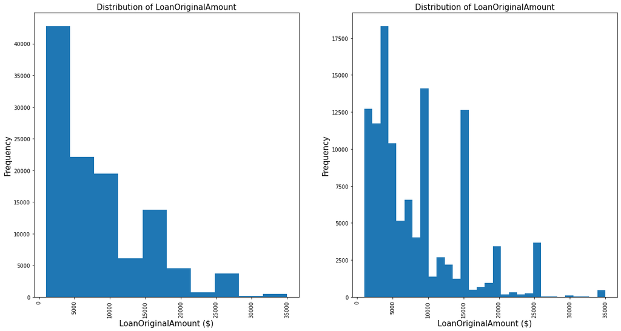

```python
hist_plot(df, 'LoanOriginalAmount', 'Distribution of LoanOriginalAmount', 'LoanOriginalAmount ($)', 'Frequency')
hist_plot2(df, 'LoanOriginalAmount', 'Distribution of LoanOriginalAmount', 'LoanOriginalAmount ($)', 'Frequency')
```

*From the above distribution shows a larger percentage of the laon collected were within 0 to 5,000$ Usd, the first plot had the distribution more sewed but the second has a more clearer representation as they are not grouped together.*

### Q2: What is the Occupational Status of the Borrowers?

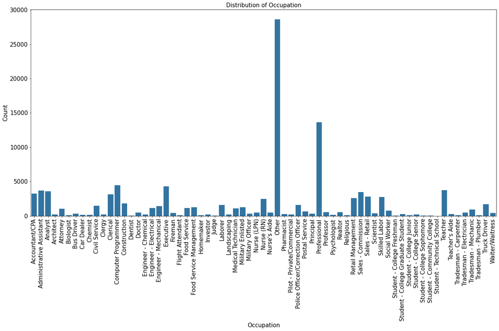

```python
fig, ax = plt.subplots(figsize = [22,10])
base_color = sb.color_palette()[0]
plt.xticks(size = 15)
plt.yticks(size = 15)
plt.xticks(rotation=90)
sb.countplot(data = df, x = 'Occupation', color = base_color);
plt.ylabel('Count', fontsize = 15)
plt.xlabel('Occupation', fontsize = 15)
plt.title('Distribution of Occupation', fontsize = 15)
plt.xticks(rotation=90);
```

*We can tell from the above visualization that most of the Borrowers occupation were recorded under the category other, which could be anyone of (A business man, Trader, Cleargy man, etc). The second largest is in the occupation Professional and so on...*

### Q3: What year recorded the hghest number of loan

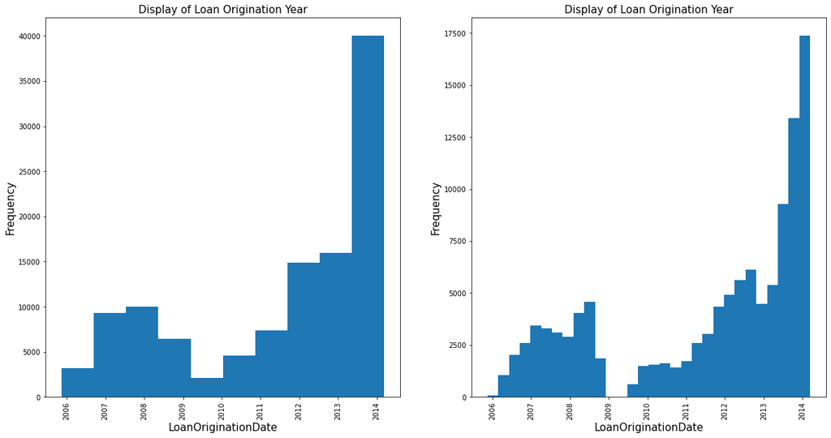

```python
bar_plot(df, 'LoanOriginationDate', 'Display of Loan Origination Year', 'LoanOriginationDate', 'Frequency')
bar_plot2(df, 'LoanOriginationDate', 'Display of Loan Origination Year', 'LoanOriginationDate', 'Frequency')
```

*We can tell from this barchart that year 2014 reccorded the highest number of loan request.* *NB: The day the listing was created is same as the loan creation date.*

### Q4: In what year were more loans payed back and transaction history closed?

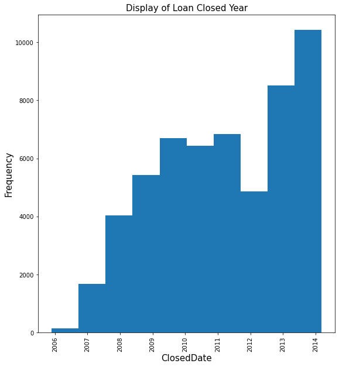

```python
bar_plot(df, 'ClosedDate', 'Display of Loan Closed Year', 'ClosedDate', 'Frequency')
```

*The above chart depicts most of the loans were payed off in 2014, followed by 2013, etc.*

### Q5: How many percentage of Borrowers were employed to other status

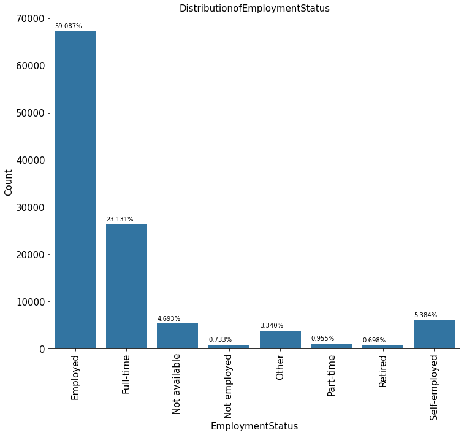

```python
fig, ax = plt.subplots(figsize = [12,10])
base_color = sb.color_palette()[0]
plt.xticks(size = 15)
plt.yticks(size = 15)
plt.xticks(rotation=90)
sb.countplot(data = df, x = 'EmploymentStatus', color = base_color);
plt.ylabel('Count', fontsize = 15)
plt.xlabel('EmploymentStatus', fontsize = 15)
plt.title('DistributionofEmploymentStatus', fontsize = 15)
for p in ax.patches:
        ax.annotate('{:.3f}%'.format((p.get_height()/df.shape[0])*100), (p.get_x()+0, p.get_height()+5),
                   ha = 'left', va = 'center_baseline', xytext = (0, 9), textcoords = 'offset points')
```

*The statistics above shows about 59.08% were employed.*

### Q6: What is the distribution of the duration of employment for each Borrower?

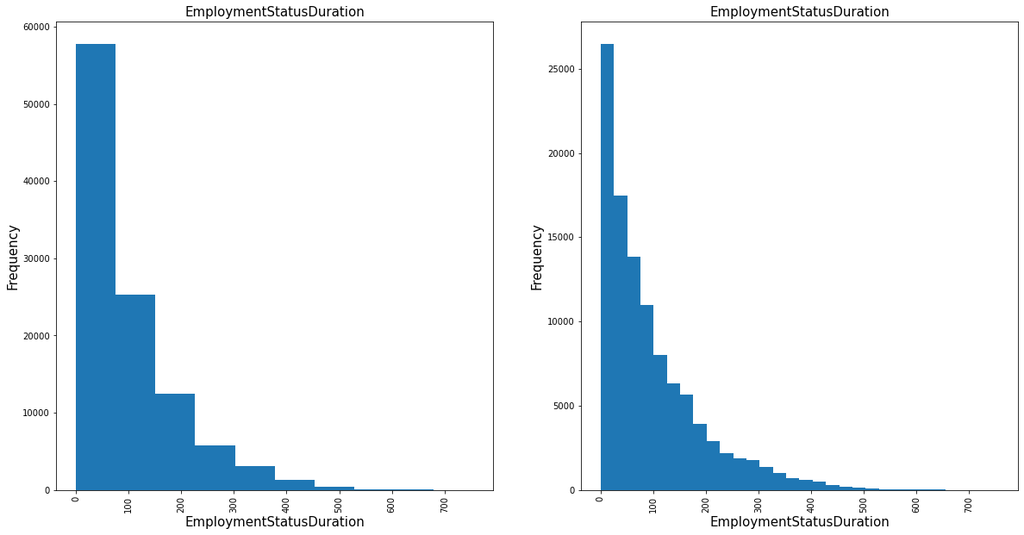

```python
bar_plot(df, 'EmploymentStatusDuration', 'EmploymentStatusDuration', 'EmploymentStatusDuration', 'Frequency')
bar_plot2(df, 'EmploymentStatusDuration', 'EmploymentStatusDuration', 'EmploymentStatusDuration', 'Frequency')### Q6: What is the distribution of the duration of employment for each Borrower?
```

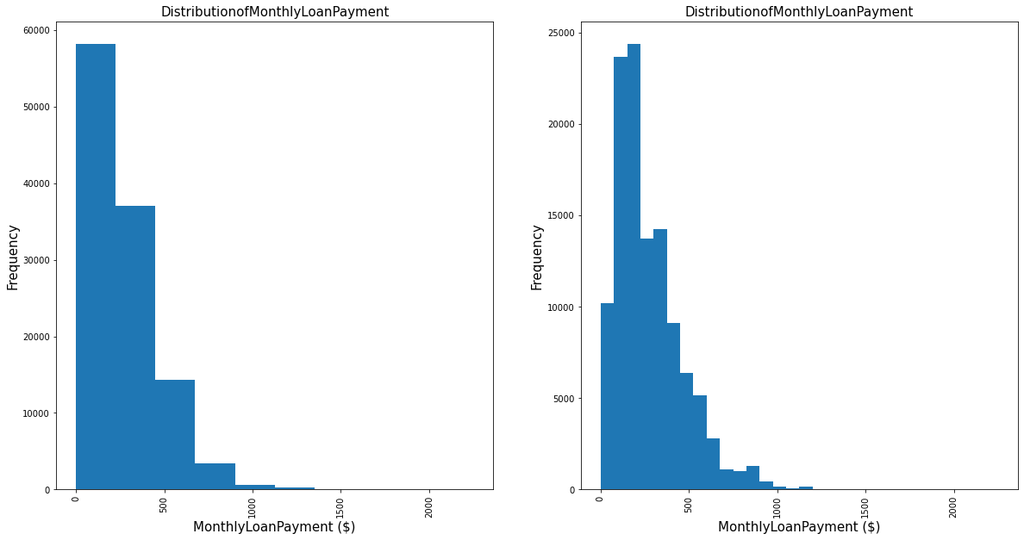

```python
np.random.seed(7)
samples = np.random.choice(df.shape[0], 10000, replace = False)
df_sample = df.loc[samples,:]
hist_plot(df, 'MonthlyLoanPayment', 'DistributionofMonthlyLoanPayment', 'MonthlyLoanPayment ($)', 'Frequency')
hist_plot2(df, 'MonthlyLoanPayment', 'DistributionofMonthlyLoanPayment', 'MonthlyLoanPayment ($)', 'Frequency')
```

### Q7: What is the distribution of income verrified to the unverified?

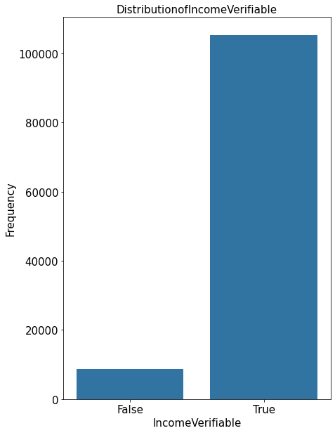

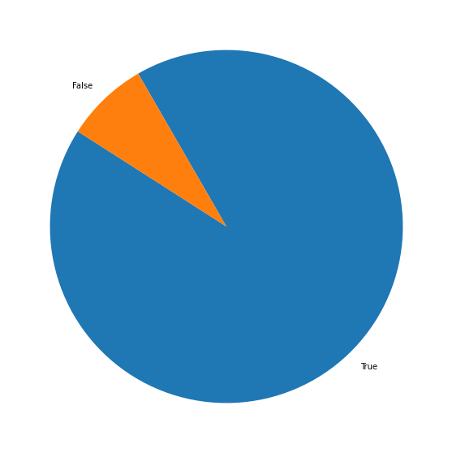

```python
fig, ax = plt.subplots(figsize = [15,10])
plt.subplot(1, 2, 1)
base_color = sb.color_palette()[0]
plt.xticks(size = 15)
plt.yticks(size = 15)
sb.countplot(data = df, x = 'IncomeVerifiable', color = base_color);
plt.ylabel('Frequency', fontsize = 15)
plt.xlabel('IncomeVerifiable', fontsize = 15)
plt.title('DistributionofIncomeVerifiable', fontsize = 15)
for p in ax.patches:
        ax.annotate('{:.3f}%'.format((p.get_height()/df.shape[0])*100), (p.get_x()+0, p.get_height()+5),
                   ha = 'left', va = 'center_baseline', xytext = (0, 9), textcoords = 'offset points')


fig, ax = plt.subplots(figsize = [10,10])
sorted_counts = df['IncomeVerifiable'].value_counts()
plt.pie(sorted_counts, labels = sorted_counts.index, startangle = 120, counterclock = False);
```

### Q8: What is the status of Loan request / application?

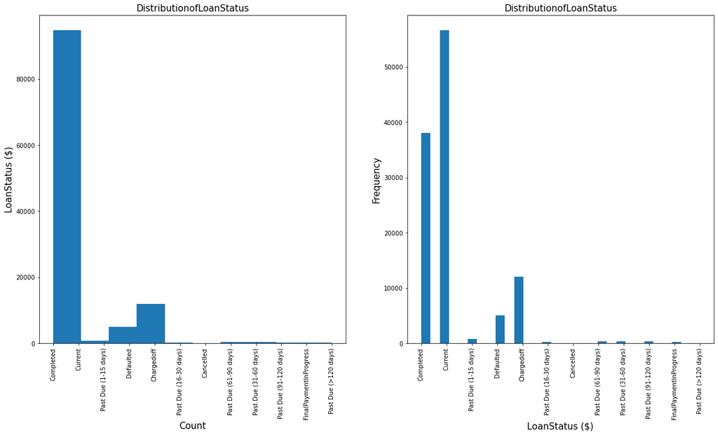

```python
hist_plot(df, 'LoanStatus', 'DistributionofLoanStatus', 'Count', 'LoanStatus ($)')
hist_plot2(df, 'LoanStatus', 'DistributionofLoanStatus', 'LoanStatus ($)', 'Frequency')
for p in ax.patches:
        ax.annotate('{:.3f}%'.format((p.get_height()/df.shape[0])*100), (p.get_x()+0, p.get_height()+5),
                   ha = 'left', va = 'center_baseline', xytext = (0, 9), textcoords = 'offset points')
```

*Only about 40,000 of the loan request have bene completed and more than 50,000 are still active (within their due dates), although some have elapsed their due dates by 1-15 days, 16-30 days, 61-90 days, 91-120 days and over 120 days.*

### Q9: Are there Borrowers that are Home owners and whats the percentage

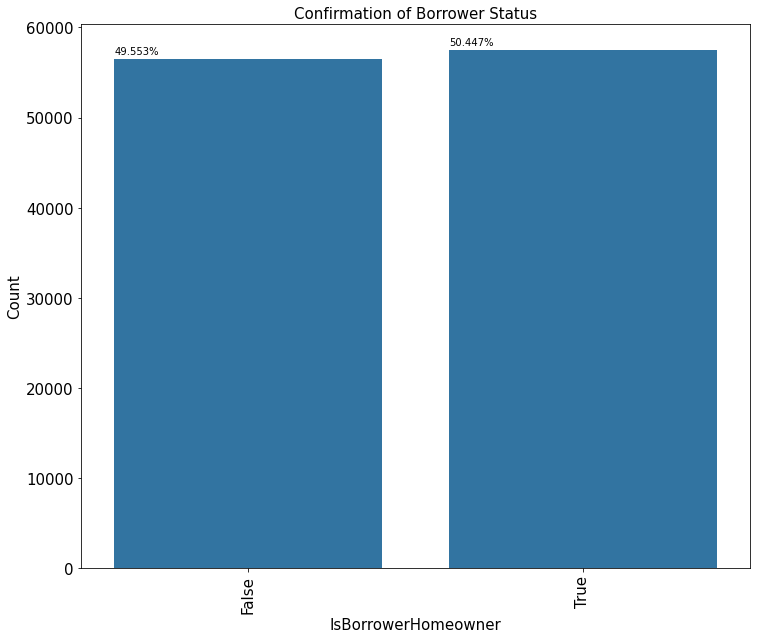

```python
fig, ax = plt.subplots(figsize = [12,10])
base_color = sb.color_palette()[0]
plt.xticks(size = 15)
plt.yticks(size = 15)
plt.xticks(rotation=90)
sb.countplot(data = df, x = 'IsBorrowerHomeowner', color = base_color);
plt.ylabel('Count', fontsize = 15)
plt.xlabel('IsBorrowerHomeowner', fontsize = 15)
plt.title('Confirmation of Borrower Status', fontsize = 15)
for p in ax.patches:
        ax.annotate('{:.3f}%'.format((p.get_height()/df.shape[0])*100), (p.get_x()+0, p.get_height()+5),
                   ha = 'left', va = 'center_baseline', xytext = (0, 9), textcoords = 'offset points')
```

*Yes, some borrowers are home owners, 50.447% of borrowers have been recorded to be home owners.*

### Univariate Summary

The IncomeVerifiable variable showed a very clear analysis of why more of the loans applied for were successful as more borrowers income were verified than not, keeping the loan company at a profit.

Before exploring the dataset, I had to change some datatypes inorder to suit my analysis, like naming the categorical datatypes over the numeric datatypes.

I also had to change the datatypes of the time piece variables to datetime, so that we can filter just the year in the analysis of the loan creation date and closed date. It was initially displaying my output in timestamp format.

The univariate visualizations was done, analyzing single variables at a time.

## Bivariate Exploration

On to the Bivariate visualization, my analysis would be based on the variables previously raised in the Univariate exploration. We would investigate the relationships between pairs of variables in our dataset.

### Below functions for the bivariate exploration are declared.

```python
# A scatter plot functor
def biplot_scatter(dataframe, x_value, y_value, title, x_label, y_label):
    plt.figure(figsize = [25,10])
    plt.subplot(1, 2, 1)
    sb.scatterplot(data = dataframe, x = x_value, y = y_value)
    #plt.scatter(data = dataframe, x = x_value, y = y_value)
    plt.title(title, size = 20)
    plt.xlabel(x_label, size = 20)
    plt.ylabel(y_label, size = 20)
    plt.xticks(size = 15)
    plt.yticks(size = 15)

# A scatter plot function with alpha value
def biplot_scatter2(dataframe, x_value, y_value, title, x_label, y_label):
    plt.subplot(1, 2, 2)
    sb.scatterplot(data = dataframe, x = x_value, y = y_value, alpha = 1/10)
    plt.title(title, size = 20)
    plt.xlabel(x_label, size = 20)
    plt.ylabel(y_label, size = 20)
    plt.xticks(size = 15)
    plt.yticks(size = 15)

# A seaborn count plot function
# If there is no plotting order, use None as the last argument
def bicount_plot(dataframe, feature, hue, title, x_label, y_label, order):
    plt.figure(figsize = [15, 10])
    ax = sb.countplot(data = dataframe, x = feature, hue = hue, order = order)
    plt.title(title, fontsize = 15)
    plt.xlabel(x_label, fontsize = 15)
    plt.ylabel(y_label, fontsize = 15)
    plt.xticks(size = 15)
    plt.yticks(size = 15);
    for p in ax.patches:
        ax.annotate('{:.3f}%'.format((p.get_height()/df.shape[0])*100), (p.get_x()+0, p.get_height()+5),
                   ha = 'left', va = 'center_baseline', xytext = (0, 9), textcoords = 'offset points')
```

### Q10: What is the Correlation between the borrower's monthly income and the loan amount, does the stated monthly income match up the borrower's loan?

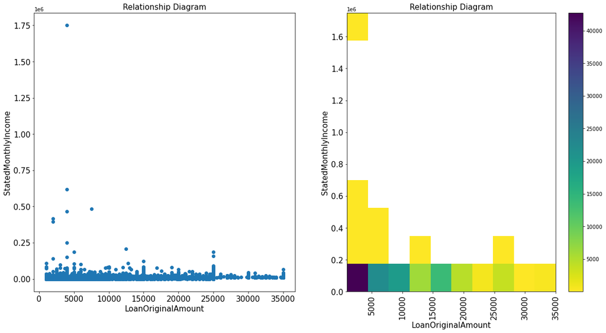

```python
## We define below the relationship bbetween Loan Original Amount and Stated Monthly Income

plt.figure(figsize = [20, 10])
plt.subplot(1, 2, 1)
plt.scatter(data = df, x = 'LoanOriginalAmount', y = 'StatedMonthlyIncome');
plt.title('Relationship Diagram', fontsize = 15)
plt.xlabel('LoanOriginalAmount', fontsize = 15)
plt.ylabel('StatedMonthlyIncome', fontsize = 15);
plt.xticks(size = 15)
plt.yticks(size = 15)

plt.subplot(1, 2, 2)
plt.hist2d(data = df, x = 'LoanOriginalAmount', y = 'StatedMonthlyIncome', cmin=0.10, cmap='viridis_r')
plt.colorbar()
plt.title('Relationship Diagram', fontsize = 15)
plt.xlabel('LoanOriginalAmount', fontsize = 15)
plt.ylabel('StatedMonthlyIncome', fontsize = 15);
plt.xticks(size = 15)
plt.yticks(size = 15)
plt.xticks(rotation=90);
```

### Q11: How many borrowers are home owners and how many home owners are investors?

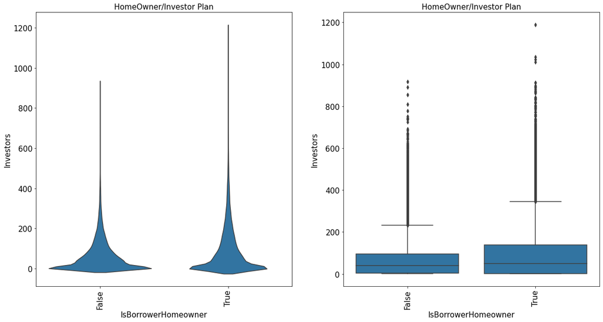

```python
# The "inner" argument represents the datapoints in the violin interior.
# It can take any value from {“box”, “quartile”, “point”, “stick”, None}
# If "box", it draws a miniature boxplot.

plt.figure(figsize = [20, 10])
base_color = sb.color_palette()[0]
plt.subplot(1, 2, 1)
sb.violinplot(data=df, x='IsBorrowerHomeowner', y='Investors', color=base_color, inner=None)
plt.title('HomeOwner/Investor Plan', fontsize = 15)
plt.xlabel('IsBorrowerHomeowner', fontsize = 15)
plt.ylabel('Investors', fontsize = 15);
plt.xticks(size = 15)
plt.yticks(size = 15)
plt.xticks(rotation=90);

plt.subplot(1, 2, 2)
sb.boxplot(data=df, x='IsBorrowerHomeowner', y='Investors', color=base_color)
plt.title('HomeOwner/Investor Plan', fontsize = 15)
plt.xlabel('IsBorrowerHomeowner', fontsize = 15)
plt.ylabel('Investors', fontsize = 15);
plt.xticks(size = 15)
plt.yticks(size = 15)
plt.xticks(rotation=90);
```

### Q12: Does the borrower's stated monthly income suffice for the monthly loan payment?

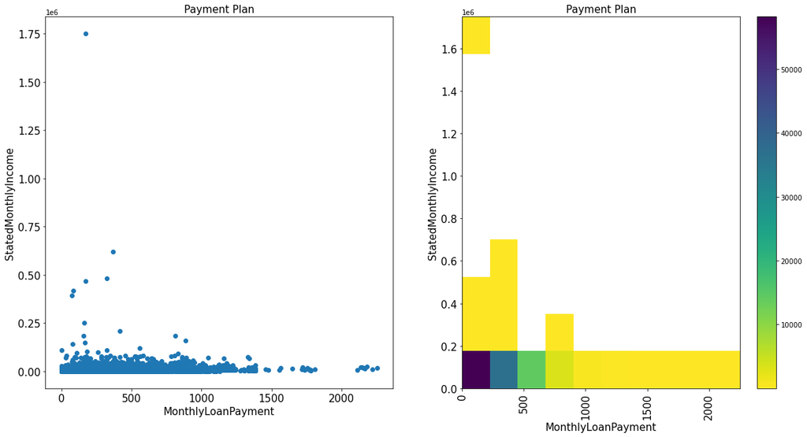

```python
plt.figure(figsize = [20, 10])
plt.subplot(1, 2, 1)
plt.scatter(data = df, x = 'MonthlyLoanPayment', y = 'StatedMonthlyIncome');
plt.title('Payment Plan', fontsize = 15)
plt.xlabel('MonthlyLoanPayment', fontsize = 15)
plt.ylabel('StatedMonthlyIncome', fontsize = 15);
plt.xticks(size = 15)
plt.yticks(size = 15)

plt.subplot(1, 2, 2)
plt.hist2d(data = df, x = 'MonthlyLoanPayment', y = 'StatedMonthlyIncome', cmin=0.10, cmap='viridis_r')
plt.colorbar()
plt.title('Payment Plan', fontsize = 15)
plt.xlabel('MonthlyLoanPayment', fontsize = 15)
plt.ylabel('StatedMonthlyIncome', fontsize = 15);
plt.xticks(size = 15)
plt.yticks(size = 15)
plt.xticks(rotation=90);
```

### Q13: What is the status of loan qpplied for from the listing numbers provided?

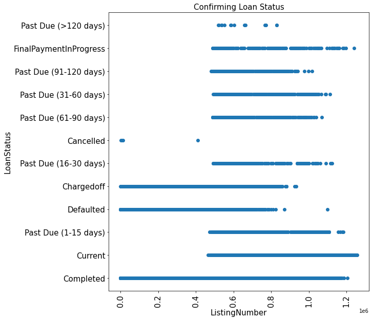

```python
#Listing creation Date vs Closed Date
#ListingCreationDate   ClosedDate
plt.figure(figsize = [20, 10])
plt.subplot(1, 2, 1)
plt.scatter(data = df, x = 'ListingNumber', y = 'LoanStatus');
plt.title('Confirming Loan Status', fontsize = 15)
plt.xlabel('ListingNumber', fontsize = 15)
plt.ylabel('LoanStatus', fontsize = 15);
plt.xticks(size = 15)
plt.yticks(size = 15)
plt.xticks(rotation=90);
for p in ax.patches:
        ax.annotate('{:.3f}%'.format((p.get_height()/df.shape[0])*100), (p.get_x()+0, p.get_height()+5),
                   ha = 'left', va = 'center_baseline', xytext = (0, 9), textcoords = 'offset points')
```

*According to the listing numbers, which uniquely identifies a loan request, we can identify the borrowers whose loan request have been completed, just through their unique ID's and not having to go through their names.*

### Q14: What is the employment status of the borrowers verrified income?

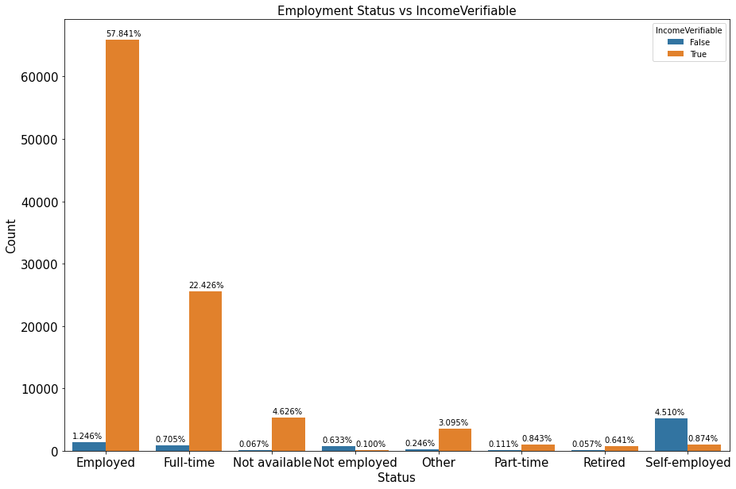

```python
bicount_plot(df, 'EmploymentStatus', 'IncomeVerifiable', 'Employment Status vs IncomeVerifiable', 'Status', 'Count', None)
```

### Bivariate Summary

In this section, we investigated the relationships between pairs of variables such as: the loan amount and the stated income of the borroer, the monthly payment and stated interest, etc.

We explored the data using the scatter plots, violin and box plots and the count plot.

## Multivariate Exploration

In the Multivariate visualization, my analysis would be based on the variables previously raised in the Bivariate exploration. We would also investigate the relationships amongst three or more variables in our dataset.

### Q15: What is the distribution of the loan created date, what are the amounts requested for and what are their current satus?

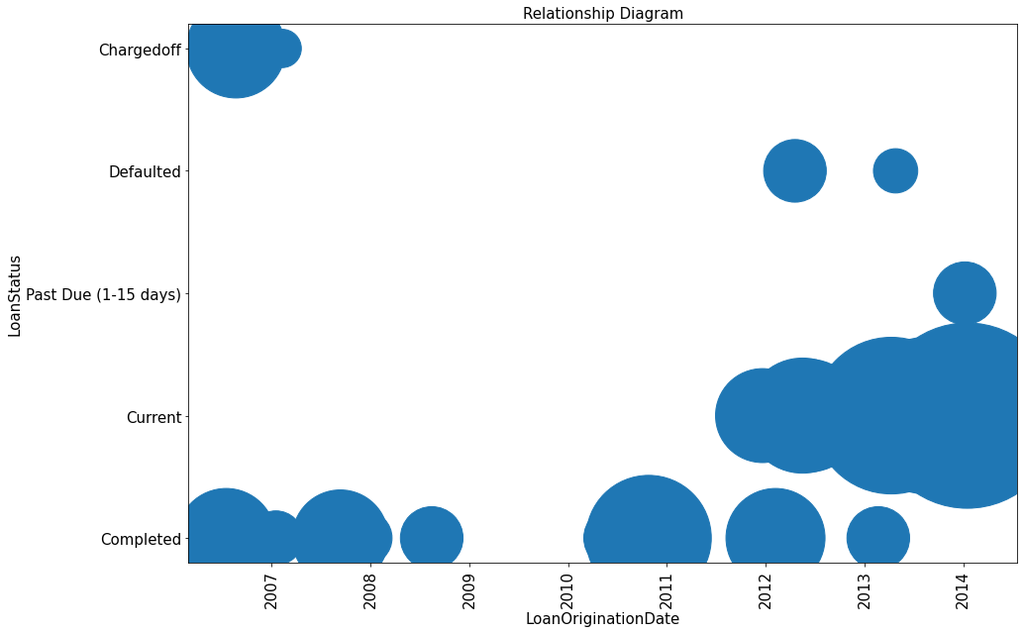

```python
plt.figure(figsize = [15, 10])
plt.scatter(data = df.head(50), x = 'LoanOriginationDate', y = 'LoanStatus', s = 'LoanOriginalAmount')
plt.title('Relationship Diagram', fontsize = 15)
plt.xlabel('LoanOriginationDate', fontsize = 15)
plt.ylabel('LoanStatus', fontsize = 15);
plt.xticks(size = 15)
plt.yticks(size = 15)
plt.xticks(rotation=90);
```

### Q16: What is the loan original amount, what is the status of the loan and when was the loan closed?

The below relationship depict that more loans were completed in 2014

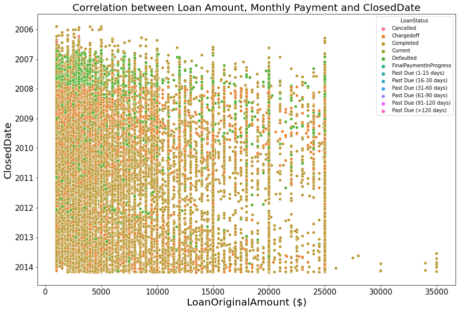

```python
def mplot_scatter(dataframe, x_value, y_value, hue, title, x_label, y_label):
    plt.figure(figsize = [15,10])
    sb.scatterplot(data = dataframe, x = x_value, y = y_value, hue = hue)
    plt.title(title, size = 20)
    plt.xlabel(x_label, size = 20)
    plt.ylabel(y_label, size = 20)
    plt.xticks(size = 15)
    plt.yticks(size = 15)

mplot_scatter(df, 'LoanOriginalAmount', 'ClosedDate', 'LoanStatus',
              'Correlation between Loan Amount, Monthly Payment and ClosedDate','LoanOriginalAmount ($)', 'ClosedDate')
```

### Multivariate Summary

In this section, we investigated the relationships amongst three or more variables, we focused on the loan creation time, the amount applied for, the status of the loan and the time loan was completed or closed.

We were able to deduced that a loan request were sucessful asper their status recorded and a good number were closed within stipulated time.

We explored the data using the scatter plots.

## Conclusions

The given dataset has been explored using the various exploration means which are the Univariate, Bivariate and Multivariate.

We've been able to deduce asper our interest in this analysis, which is to understand why some loan application were more successful over the others.

We used Histogram plots, barchart, Scatter plot, violin and box plots for visualization in our analysis.